# Obtaining and using access tokens

rtweet: Collecting Twitter Data

This vignette covers how to obtain and use Twitter API access tokens for use in the `rtweet` package.

```r
# install from CRAN
install.packages("rtweet")

# load rtweet
library(rtweet)
```

## Create Twitter App

- To create a Twitter app, [click here](https://apps.twitter.com/) and decide on a `Name`, `Description`, and `Website` for your app (example screenshot provided below).
- **Important** In the `Callback URL` field, make sure to enter the following: `http://127.0.0.1:1410`
- Check yes if you agree and then click “Create your Twitter application”.

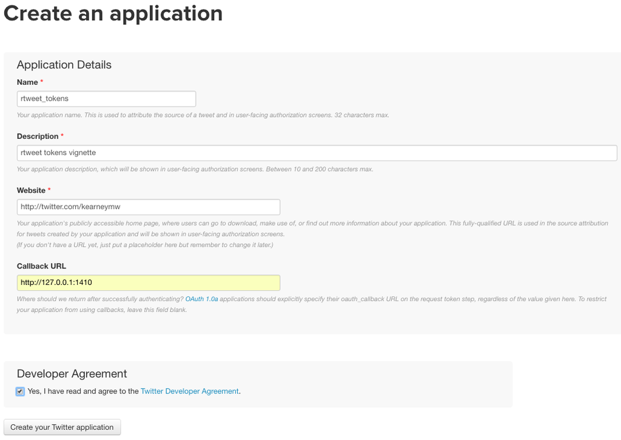

- Once you’ve successfully created an app, click on the `Keys and Access Tokens` tab and copy down your consumer (api) and secret keys.

[figure not shown]

- The keys you you’ll need to create a token are the `Consumer Key` (aka API Key) and the `Consumer Secret` (aka API Secret).
- I’ve highlighted the keys in the screen shot below.

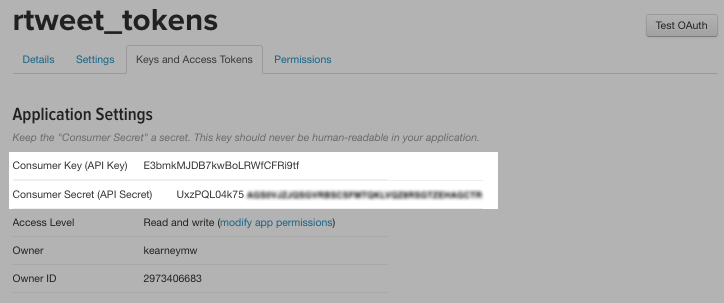

*NOTE*: Following the steps outlined above, it’s possible to create *multiple* Twitter apps, resulting in multiple tokens. Twitter discourages abusing their API rate limits (these are like speed limits, regulating the amount of requests you can make within a given period of time). Abusing Twitter rate limits can even result in Twitter completely revoking your API access. However, using a small number of tokens seems to fall well below their threshold of concern.

## Using Tokens with `rtweet`

- With the access keys identified earlier, use `create_token()` and store the output as `twitter_tokens`.

```r
twitter_tokens <- c(
  create_token(app = "rtweet_tokens", #whatever you named your app
    consumer_key = "XZgqotgOZNKlLFJqFbd8NjUtL",
    consumer_secret = "1rDnU3H3nrxxxxxxxxxxxxxxxxxxxxxxxxxxxxxxxxxxxxxxxx"),
  create_token(app = "rtweet_roauth",
    consumer_key = "XZgqoxxxxxxxxxxxxxxxxxxxx",
    consumer_secret = "1rDnU3H3nrxxxxxxxxxxxxxxxxxxxxxxxxxxxxxxxxxxxxxxxx")
  )
# (xxxxx's added but you get the point)
```

## Saving Tokens

- At this point, you technically have enough to start using `rtweet` functions; you’d just need to set the `token` argument equal to `twitter_tokens` (the object created earlier).
- Rather than creating tokens every time you open R, remembering where you saved your token(s) or passwords, and specifying a token every time you use a function, you can also store your tokens as an environment variable.
- To do this, save the `twitter_tokens` object we created earlier in your home directory. To locate your home directory enter `normalizePath("~/")` into your R console (the home directory on my mac, for example, is “/Users/mwk/”).
- Now, `save()` the `twitter_tokens` object to the desired file location. I used the code below to as a shortcut to generate the file path (“/Users/mwk/twitter_tokens”) for my tokens object.

```r
home_directory <- normalizePath("~/")
file_name <- paste0(home_directory, "/", "twitter_tokens")
save(twitter_tokens, file = file_name)
```

- Next you’ll need to create an environment variable. This makes it easy to access your token(s) in future sessions (a best practice [recommended by Hadley](https://github.com/hadley/httr/blob/master/vignettes/api-packages.Rmd)).

## Environment Variable

- Create a plain text file containing the path to your tokens object and save it to your home directory as “.Renviron”.
- To create a plain text file in R, modify the code below. Change the TWITTER_PAT location to match the path you used earlier (in the example below, you’d want to change “/Users/mwk/twitter_tokens”). You can also create a plain text document in any text editor like TextEdit or Notepad. If you’re using Rstudio, select File > New File > Text File.
- **Important**: Make sure the last line of “.Renviron” is blank. I achieved this in the code below by including `\n`.

```r
cat("TWITTER_PAT=/Users/mwk/twitter_tokens\n",
  file = paste0(home_directory, "/.Renviron"),
  append = TRUE)
```

- Restart R so it can process the environment variable.
- If you completed the steps successfully, you should be able to use `rtweet` functions without specifying [or even *thinking* about] tokens [ever again]. If you have more than one token, rtweet will even quickly cycle through tokens to navigate API rate limits.

That’s it!